# Comp App Trans AY2024 Homework

## ==== First things first ====

Set working directory and call packages.

```r
# Check current working directory
getwd()
```

```
## [1] "C:/Users/Terxzera/Desktop/R_lang/chula_comp_app_trans/hw"
```

```r
# Set working directory
"C:/Users/Terxzera/Desktop/R_lang/chula_comp_app_trans/hw"
```

```
## [1] "C:/Users/Terxzera/Desktop/R_lang/chula_comp_app_trans/hw"
```

```r
# Call required packages, ex. "readxl", "tidyverse"
if(!require(readxl)){install.packages("readxl")}
if(!require(tidyverse)){install.packages("tidyverse")}
if(!require(gapminder)){install.packages("gapminder")}
```

## ==== Question 2 ====

**Step 1:** เรียกใช้ R built-in data ชื่อ gapminder ใน **library(gapminder)** แล้วสร้างเป็น object ชื่อ gap_data (0.5 คะแนน)

- country factor with 142 levels
- continent factor with 5 levels
- year ranges from 1952 to 2007 in increments of 5 years
- lifeExp life expectancy at birth, in years
- pop population
- gdpPercap GDP per capita (US$, inflation-adjusted)

**Step 2:** นับจำนวนประเทศที่อยู่ในทวีปเอเซีย (Asia) และค่ามัธยฐานของอายุคาดเฉลี่ย (life expectancy) ของทุกประเทศในทวีปเอเซีย (Asia) ในปี 2002 โดยแสดงผลในตัวแปรชื่อ n_countries และ lifeExp_med ตามลำดับ (0.5 คะแนน)

**Step 3:** สร้างตารางสรุปจำนวนประชากร (Pop) และขนาดของเศรษฐกิจ (Total_GDP = pop * gdpPercap) จำแนกรายทวีป ในปี 2002 โดยเรียงข้อมูลใหม่ตามขนาดของเศรษฐกิจ (Total_GDP) (1 คะแนน)

*Hint**: สร้างคอลัมน์ใหม่แสดงขนาดของเศรษฐกิจ (Total GDP) โดยใช้ฟังก์ชัน* `mutate`

**Step 4:** สร้างตารางแสดงค่า GDP per capita ของประเทศ China, Japan และ South Korea ตั้งแต่ปี 1980 โดยแสดงข้อมูลในรูปแบบ wide format กำหนดให้ ปี เป็น row header และชื่อประเทศเป็น column header (1 คะแนน)

*Hint**: เปลี่ยนข้อมูลแบบ long ให้เป็นข้อมูลแบบ wide ด้วยคำสั่ง* `pivot_wider` *หรือ* `spread`

**Step 5:** สร้างคอลัมน์ใหม่ให้ object ชื่อ gap_data โดยตั้งชื่อว่า “continent.f” ซึ่งเปลี่ยนลำดับ (level) ของ continent ตามจำนวนข้อมูล (the number of observations) จากน้อยไปหามาก โดยใช้คำสั่ง `fct_infreq()` และ `fct_rev()` จากนั้นเขียน 1 คำสั่งเพื่อแสดงลำดับของทวีปที่มีจำนวนประเทศจากน้อยไปหามาก (1 คะแนน)

```r
# ติดตั้งและเรียกใช้ library ที่จำเป็น

# Step 1
gap_data <- gapminder
glimpse(gap_data)
```

```
## Rows: 1,704
## Columns: 6
## $ country   <fct> "Afghanistan", "Afghanistan", "Afghanistan", "Afghanistan", …
## $ continent <fct> Asia, Asia, Asia, Asia, Asia, Asia, Asia, Asia, Asia, Asia, …
## $ year      <int> 1952, 1957, 1962, 1967, 1972, 1977, 1982, 1987, 1992, 1997, …
## $ lifeExp   <dbl> 28.801, 30.332, 31.997, 34.020, 36.088, 38.438, 39.854, 40.8…
## $ pop       <int> 8425333, 9240934, 10267083, 11537966, 13079460, 14880372, 12…
## $ gdpPercap <dbl> 779.4453, 820.8530, 853.1007, 836.1971, 739.9811, 786.1134, …
```

```r
# Step 2
asia_2002_data <- gap_data %>%
  filter(continent == "Asia" & year == 2002)

n_countries <- nrow(asia_2002_data)
lifeExp_med <- median(asia_2002_data$lifeExp)

print(paste("จำนวนประเทศในเอเซีย:", n_countries))
```

```
## [1] "จำนวนประเทศในเอเซีย: 33"
```

```r
print(paste("ค่ามัธยฐานอายุคาดเฉลี่ย:", lifeExp_med))
```

```
## [1] "ค่ามัธยฐานอายุคาดเฉลี่ย: 71.028"
```

```r
# Step 3
gdp_summary_2002 <- gap_data %>%
  filter(year == 2002) %>%
  mutate(Total_GDP = pop * gdpPercap) %>%
  group_by(continent) %>%
  summarise(
    Total_Pop = sum(pop),
    Total_GDP = sum(Total_GDP)
  ) %>%
  arrange(desc(Total_GDP))

print(gdp_summary_2002)
```

```
## # A tibble: 5 × 3
##   continent  Total_Pop Total_GDP
##   <fct>          <dbl>     <dbl>
## 1 Americas   849772762   1.65e13
## 2 Asia      3601802203   1.51e13
## 3 Europe     578223869   1.31e13
## 4 Africa     833723916   1.84e12
## 5 Oceania     23454829   6.90e11
```

```r
# Step 4
gdp_wide <- gap_data %>%
  filter(country %in% c("China", "Japan", "Korea, Rep."), year >= 1980) %>%
  select(year, country, gdpPercap) %>%
  pivot_wider(names_from = country, values_from = gdpPercap)

print(gdp_wide)
```

```
## # A tibble: 6 × 4
##    year China  Japan `Korea, Rep.`
##   <int> <dbl>  <dbl>         <dbl>
## 1  1982  962. 19384.         5623.
## 2  1987 1379. 22376.         8533.
## 3  1992 1656. 26825.        12104.
## 4  1997 2289. 28817.        15994.
## 5  2002 3119. 28605.        19234.
## 6  2007 4959. 31656.        23348.
```

```r
# Step 5
gap_data <- gap_data %>%
  mutate(continent.f = fct_rev(fct_infreq(continent)))

print(levels(gap_data$continent.f))
```

```
## [1] "Oceania"  "Americas" "Europe"   "Asia"     "Africa"
```

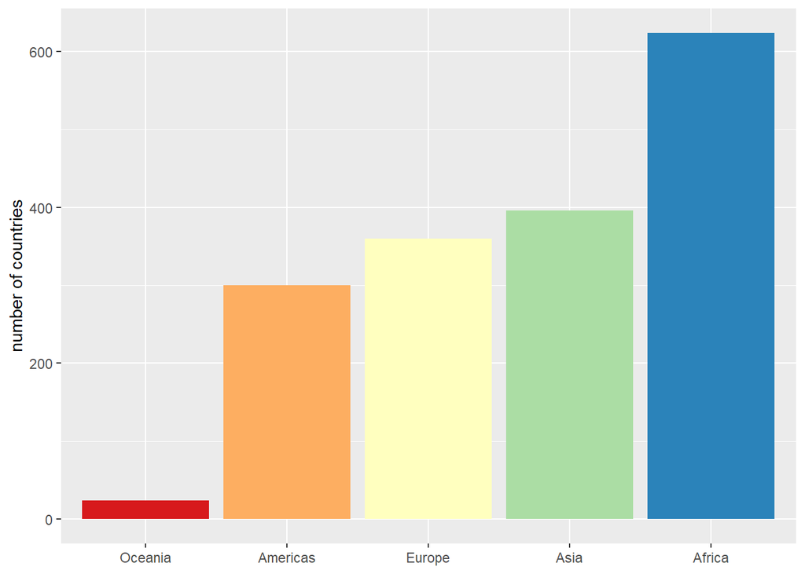

```r
# Step 6
ggplot(gap_data, aes(x = continent.f, fill = continent.f)) +
  geom_bar(show.legend = FALSE) +
  scale_fill_brewer(palette = "Spectral") +
  labs(y = "number of countries", x = NULL)
```

Student ID:6730525021

==== End-of-File ====